ANALISIS HUBUNGAN FREKUENSI PENYEWAAN DAN REVENUE FILM PADA DATABASE SAKILA

Rafeyfa Chayara Alima-M0725050

Pendahuluan

Industri penyewaan film merupakan salah satu bentuk layanan hiburan yang mengandalkan pemahaman terhadap preferensi pelanggan untuk meningkatkan pendapatan. Dalam operasionalnya, perusahaan perlu mengetahui film-film yang paling diminati pelanggan serta kontribusinya terhadap pendapatan yang dihasilkan. Informasi tersebut dapat digunakan untuk mengevaluasi kinerja katalog film, mengoptimalkan strategi pemasaran, dan mendukung pengambilan keputusan yang lebih efektif dalam pengelolaan inventaris film.

Data transaksi merupakan sumber informasi yang penting dalam memahami perilaku pelanggan dan mengevaluasi kinerja bisnis. Data transaksi dapat digunakan untuk mengetahui film yang paling diminati pelanggan serta kontribusinya terhadap pendapatan perusahaan. Salah satu cara untuk memperoleh informasi tersebut adalah melalui analisis statistik. Dengan menggunakan analisis statistik, hubungan antara tingkat popularitas film dan pendapatan yang dihasilkan dapat dipelajari secara lebih objektif. Popularitas film dapat diukur melalui frekuensi penyewaan, sedangkan kinerja finansial dapat dilihat dari revenue yang diperoleh.

Laporan ini bertujuan untuk menganalisis hubungan antara frekuensi penyewaan film dan revenue pada database Sakila menggunakan eksplorasi data, visualisasi, korelasi Pearson, dan regresi linear sederhana. Hasil analisis diharapkan dapat memberikan insight mengenai pengaruh popularitas film terhadap pendapatan yang dihasilkan.

Database Sakila

Insight yang diambil dalam analisis ini adalah “Analisis Hubungan Frekuensi Penyewaan dan Revenue Film pada Database Sakila”. Variabel yang digunakan meliputi Revenue sebagai variabel dependen yang merepresentasikan total pendapatan film dan Rental Count sebagai variabel independen yang menunjukkan frekuensi penyewaan film. Selain itu, Title digunakan sebagai variabel identifikasi untuk membedakan masing-masing film. Variabel film_id digunakan sebagai identitas unik setiap film dalam database. Analisis difokuskan pada hubungan antara frekuensi penyewaan dan revenue untuk mengetahui apakah film yang lebih sering disewa cenderung menghasilkan pendapatan yang lebih tinggi.

Tujuan Analisis

1. Menghitung frekuensi penyewaan setiap film
2. Menghitung revenue yang dihasilkan setiap film
3. Menganalisis hubungan antara frekuensi penyewaan dan revenue
4. Menentukan apakah hubungan tersebut signifikan secara statistik

Deskripsi Data

Data diperoleh dari database Sakila menggunakan query SQL berikut:

```sql
SELECT
    f.film_id,
    f.title,
    COUNT(r.rental_id) AS rental_count,
    SUM(p.amount) AS revenue
FROM film f
JOIN inventory i
    ON f.film_id = i.film_id
JOIN rental r
    ON i.inventory_id = r.inventory_id
JOIN payment p
    ON r.rental_id = p.rental_id
GROUP BY f.film_id, f.title
ORDER BY rental_count DESC;
```

Import Data

```r
data <- read.csv("~/film_revenue.csv")
```

Random Sampling

Dataset yang digunakan dalam analisis ini memiliki 300 observasi yang diambil dari Database Sakila melalui metode random sampling.

```r
set.seed(123)
data_sakila <- data[sample(nrow(data), 300),]
View(data_sakila)
```

Eksplorasi Data

Eksplorasi data dilakukan untuk memahami struktur dan karakteristik dataset yang digunakan dalam analisis. Fungsi summary(), str(), dan dim() digunakan untuk memperoleh gambaran umum data, sedangkan head() dan View() digunakan untuk melihat contoh isi data.

```r
summary(data$rental_count)
```

```
##    Min. 1st Qu.  Median    Mean 3rd Qu.    Max.
##    4.00   11.00   16.00   16.75   22.00   34.00
```

```r
summary(data$revenue)
```

```
##    Min. 1st Qu.  Median    Mean 3rd Qu.    Max.
##    5.94   37.74   62.32   70.36   95.75  231.73
```

```r
summary(data_sakila)
```

```
##     film_id         title            rental_count      revenue
##  Min.   :  3.0   Length:300         Min.   : 4.00   Min.   :  5.95
##  1st Qu.:287.2   Class :character   1st Qu.:11.00   1st Qu.: 39.77
##  Median :553.5   Mode  :character   Median :16.50   Median : 59.34
##  Mean   :533.0                      Mean   :16.72   Mean   : 69.80
##  3rd Qu.:791.2                      3rd Qu.:22.00   3rd Qu.: 92.84
##  Max.   :999.0                      Max.   :32.00   Max.   :204.72
```

```r
str(data_sakila)
```

```
## 'data.frame':    300 obs. of  4 variables:
##  $ film_id     : int  709 717 320 975 816 959 516 309 147 500 ...
##  $ title       : chr  "RACER EGG" "REAR TRADING" "FLAMINGOS CONNECTICUT" "WILLOW TRACY" ...
##  $ rental_count: int  18 17 23 16 23 6 9 25 20 22 ...
##  $ revenue     : num  57.8 32.8 139.8 58.8 72.8 ...
```

```r
dim(data_sakila)
```

```
## [1] 300   4
```

```r
head(data_sakila)
```

```
##     film_id                 title rental_count revenue
## 415     709             RACER EGG           18   57.82
## 463     717          REAR TRADING           17   32.83
## 179     320 FLAMINGOS CONNECTICUT           23  139.77
## 526     975          WILLOW TRACY           16   58.84
## 195     816 SNOWMAN ROLLERCOASTER           23   72.77
## 938     959      WARLOCK WEREWOLF            6   21.94
```

```r
View(data_sakila)
```

Key Performance Indicators

Untuk memperoleh gambaran umum mengenai performa film pada database Sakila, dilakukan perhitungan beberapa indikator utama yang terdiri atas total revenue, rata-rata revenue per film, rata-rata frekuensi penyewaan, dan jumlah film yang dianalisis.

```r
total_revenue <- sum(data_sakila$revenue)
avg_revenue <- mean(data_sakila$revenue)
avg_rental <- mean(data_sakila$rental_count)
jumlah_film <- nrow(data_sakila)

kpi <- data.frame(
  Indikator = c(
    "Total Revenue",
    "Rata-rata Revenue",
    "Rata-rata Rental",
    "Jumlah Film"
  ),
  Nilai = c(
    total_revenue,
    avg_revenue,
    avg_rental,
    jumlah_film
  )
)

kpi
```

```
##           Indikator       Nilai
## 1     Total Revenue 20940.77000
## 2 Rata-rata Revenue    69.80257
## 3  Rata-rata Rental    16.72333
## 4       Jumlah Film   300.00000
```

Hasil KPI ini memberikan gambaran awal bahwa aktivitas penyewaan film pada database Sakila cukup aktif. Namun, masih diperlukan analisis lebih lanjut untuk mengetahui apakah film yang memiliki frekuensi penyewaan tinggi juga cenderung menghasilkan revenue yang lebih besar.

Visualisasi

Top 10 Film dengan Frekuensi Penyewaan Tertinggi

```r
library(tidyverse)
```

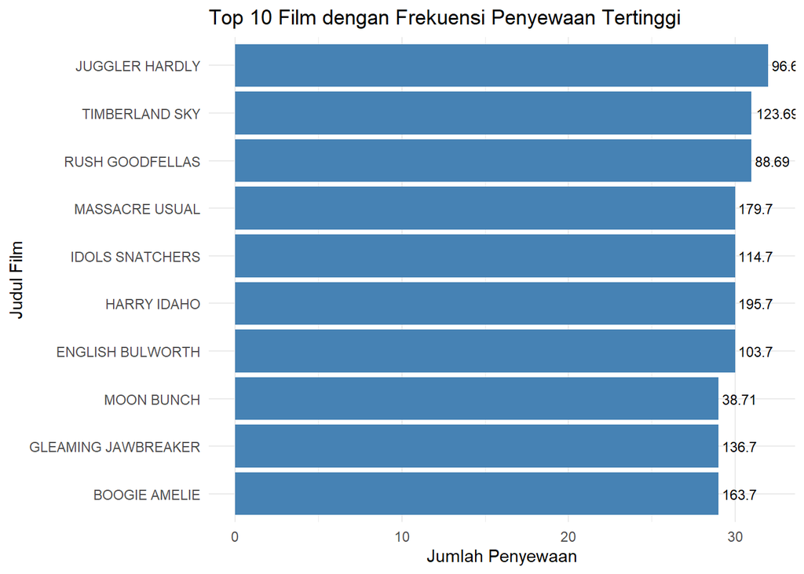

```r
library(ggplot2)

top10 <- data_sakila %>%
  arrange(desc(rental_count)) %>%
  head(10)

ggplot(top10,
       aes(x = reorder(title, rental_count),
           y = rental_count)) +
  geom_col(fill = "steelblue") +
  geom_text(
    aes(label = round(revenue, 2)),
    hjust = -0.1,
    size = 3) +
  coord_flip() +
  labs(
    title = "Top 10 Film dengan Frekuensi Penyewaan Tertinggi",
    x = "Judul Film",
    y = "Jumlah Penyewaan") +
  theme_minimal()
```

Tingginya frekuensi penyewaan menunjukkan adanya minat pelanggan yang besar terhadap film-film tersebut. Informasi ini memberikan gambaran awal mengenai preferensi pelanggan dan dapat digunakan untuk mengidentifikasi film yang memiliki potensi kontribusi besar terhadap pendapatan. Namun, diperlukan analisis lebih lanjut untuk mengetahui apakah film yang paling sering disewa juga menghasilkan revenue yang lebih tinggi.

Top 10 Film dengan Revenue Tertinggi

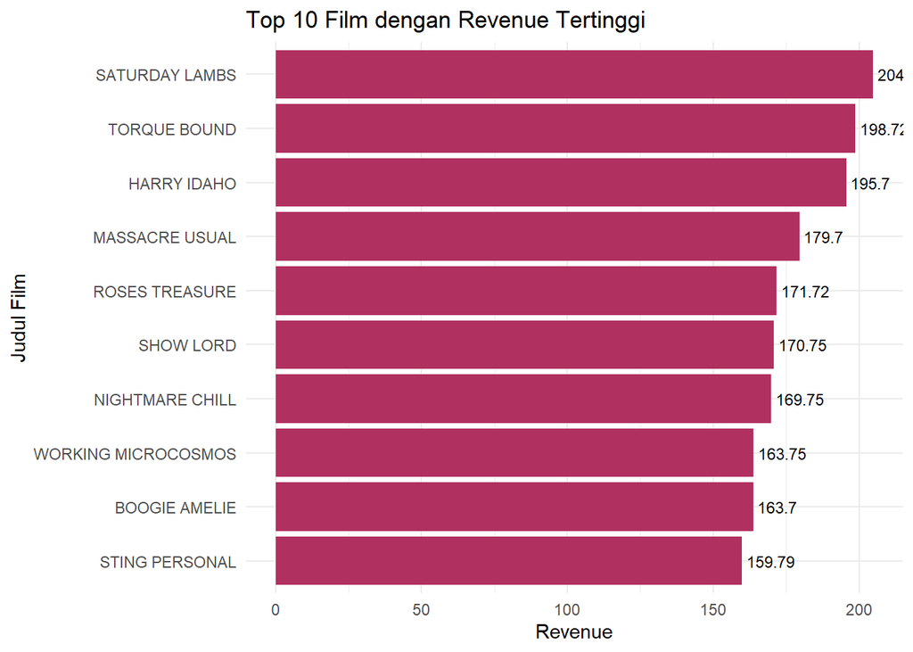

```r
top10 <- data_sakila %>%
  arrange(desc(revenue)) %>%
  head(10)

ggplot(top10,
       aes(x = reorder(title, revenue),
           y = revenue)) +
  geom_col(fill = "maroon") +
  geom_text(
    aes(label = round(revenue, 2)),
    hjust = -0.1,
    size = 3) +
  coord_flip() +
  labs(
    title = "Top 10 Film dengan Revenue Tertinggi",
    x = "Judul Film",
    y = "Revenue") +
  theme_minimal()
```

Grafik menunjukkan 10 film dengan revenue tertinggi pada database Sakila. Terlihat bahwa terdapat perbedaan pendapatan yang dihasilkan oleh masing-masing film. Film Saturday Lambs merupakan film yang memberikan pendapatan paling tinggi dibandingkan film lainnya. Hasil ini menunjukkan bahwa kemampuan suatu film dalam menghasilkan revenue tidak hanya ditentukan oleh keberadaannya dalam katalog, tetapi juga oleh tingkat permintaan pelanggan terhadap film tersebut. Dengan membandingkan visualisasi ini dengan grafik frekuensi penyewaan sebelumnya, dapat diperoleh gambaran awal mengenai apakah film yang paling sering disewa juga menjadi film dengan revenue tertinggi.

Scatter Plot Hubungan Frekuensi Penyewaan dan Revenue

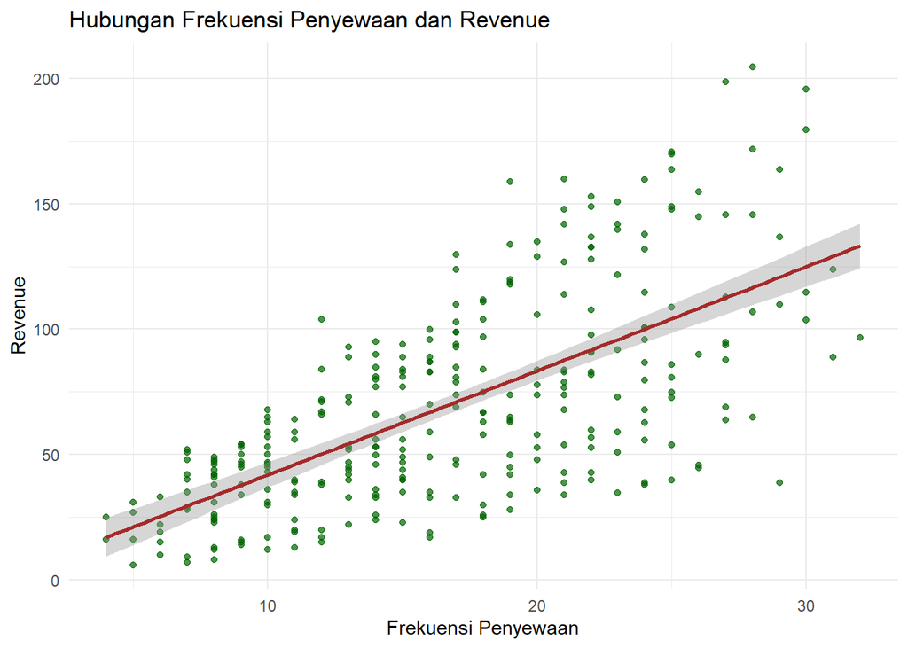

```r
ggplot(data_sakila,
       aes(x = rental_count,
           y = revenue)) +
  geom_point(color = "darkgreen", alpha = 0.7) +
  geom_smooth(method = "lm",
              se = TRUE,
              color = "brown") +
  labs(
    title = "Hubungan Frekuensi Penyewaan dan Revenue",
    x = "Frekuensi Penyewaan",
    y = "Revenue") +
  theme_minimal()
```

Scatter plot menunjukkan hubungan antara frekuensi penyewaan dan revenue yang dihasilkan oleh setiap film. Setiap titik merepresentasikan satu film, dengan sumbu horizontal menunjukkan jumlah penyewaan dan sumbu vertikal menunjukkan revenue yang diperoleh. Secara visual terlihat adanya kecenderungan hubungan positif antara kedua variabel. Hal ini ditunjukkan oleh pola titik yang cenderung meningkat seiring bertambahnya frekuensi penyewaan serta garis regresi yang memiliki arah naik. Dengan demikian, film yang lebih sering disewa cenderung menghasilkan revenue yang lebih tinggi.

Analisis Data

Analisis Korelasi Pearson

Korelasi Pearson digunakan untuk mengukur kekuatan dan arah hubungan linear antara dua variabel numerik, yaitu frekuensi penyewaan film dan revenue. Rumus koefisien korelasi Pearson:
$$r=
\frac{\sum_{i=1}^{n}(x_i-\bar{x})(y_i-\bar{y})}
{\sqrt{\sum_{i=1}^{n}(x_i-\bar{x})^2}
\sqrt{\sum_{i=1}^{n}(y_i-\bar{y})^2}}$$

Hipotesis

$$H_0:\rho = 0$$
Tidak terdapat hubungan antara frekuensi penyewaan dan revenue.

$$H_1:\rho \neq 0$$
Terdapat hubungan antara frekuensi penyewaan dan revenue.

```r
cor.test(
data_sakila$rental_count,
data_sakila$revenue)
```

```
##
##  Pearson's product-moment correlation
##
## data:  data_sakila$rental_count and data_sakila$revenue
## t = 15.204, df = 298, p-value < 2.2e-16
## alternative hypothesis: true correlation is not equal to 0
## 95 percent confidence interval:
##  0.5920154 0.7202771
## sample estimates:
##       cor
## 0.6609462
```

Berdasarkan hasil uji korelasi Pearson, diperoleh nilai koefisien korelasi sebesar 0,661 yang menunjukkan adanya hubungan positif antara frekuensi penyewaan dan revenue. Artinya, film yang lebih sering disewa cenderung menghasilkan revenue yang lebih tinggi. Selain itu, diperoleh nilai p-value < 0,05 sehingga H0 ditolak. Dengan demikian, terdapat hubungan yang signifikan antara frekuensi penyewaan dan revenue pada film.

Regresi Linear

Regresi linear sederhana digunakan untuk mengetahui pengaruh variabel independen terhadap variabel dependen. Pada analisis ini, Rental Count digunakan sebagai variabel independen, sedangkan Revenue digunakan sebagai variabel dependen.

$$Revenue = \beta_0 + \beta_1(RentalCount) + \varepsilon$$
Keterangan: Revenue = total pendapatan film RentalCount = frekuensi penyewaan film β0 = nilai revenue yang diprediksi ketika RentalCount = 0 β1 = perubahan rata-rata revenue untuk setiap kenaikan 1 unit rental count ε = galat (error)

```r
model <- lm(
revenue ~ rental_count,
data = data_sakila
)

summary(model)
```

```
##
## Call:
## lm(formula = revenue ~ rental_count, data = data_sakila)
##
## Residuals:
##     Min      1Q  Median      3Q     Max
## -82.078 -21.899  -2.643  20.327  88.085
##
## Coefficients:
##              Estimate Std. Error t value Pr(>|t|)
## (Intercept)    0.3493     4.9067   0.071    0.943
## rental_count   4.1531     0.2732  15.204   <2e-16 ***
## ---
## Signif. codes:  0 '***' 0.001 '**' 0.01 '*' 0.05 '.' 0.1 ' ' 1
##
## Residual standard error: 31.03 on 298 degrees of freedom
## Multiple R-squared:  0.4368, Adjusted R-squared:  0.435
## F-statistic: 231.2 on 1 and 298 DF,  p-value: < 2.2e-16
```

Berdasarkan hasil regresi linear, diperoleh model: Revenue = 0,349 + 4,153(RentalCount)

Koefisien Rental Count sebesar 4,153 menunjukkan bahwa setiap peningkatan satu kali penyewaan diperkirakan akan meningkatkan revenue sebesar 4,153 satuan. Sementara itu, nilai intercept sebesar 0,349 menunjukkan revenue yang diprediksi ketika frekuensi penyewaan bernilai nol.
$$R^2=
\frac{SSR}{SST}$$
Berdasarkan hasil regresi linear, diperoleh nilai R² sebesar 0,437 atau 43,7%. Hal ini menunjukkan bahwa frekuensi penyewaan mampu menjelaskan sekitar 43,7% variasi revenue, sedangkan sisanya sebesar 56,3% dipengaruhi oleh faktor lain di luar model. Selain itu, diperoleh p-value < 0,05 yang berarti frekuensi penyewaan berpengaruh signifikan terhadap revenue.

Kesimpulan

Berdasarkan hasil analisis pada database Sakila, diperoleh gambaran bahwa aktivitas penyewaan film berkontribusi terhadap pendapatan yang dihasilkan. Hasil visualisasi menunjukkan adanya perbedaan frekuensi penyewaan dan revenue antar film yang mengindikasikan bahwa tingkat popularitas film tidak tersebar secara merata. Film dengan frekuensi penyewaan yang lebih tinggi cenderung memiliki kontribusi pendapatan yang lebih besar dibandingkan film lainnya.

Hasil uji korelasi Pearson menunjukkan adanya hubungan positif yang kuat dan signifikan antara frekuensi penyewaan dan revenue dengan nilai koefisien korelasi sebesar 0,661. Selain itu, analisis regresi linear menunjukkan bahwa frekuensi penyewaan berpengaruh signifikan terhadap revenue, dengan nilai koefisien determinasi sebesar 43,7%. Dengan demikian, dapat disimpulkan bahwa semakin tinggi frekuensi penyewaan suatu film, semakin tinggi pula revenue yang dihasilkan, meskipun masih terdapat faktor lain di luar model yang turut memengaruhi pendapatan film.